# Energy_analysis_index_system

XinzeTang

2019/12/21

# 4 Energy Performance Index

After we have done some of the descriptive analysis of the energy data, we finally need to propose a method to evaluate the performance of each state. Because where exists a large number of variables that correlated to the performance, we didn’t do the descriptive analysis for all the variables. Here we try to establish a system, that we called it as Energy Perform Index, to do the evaluation. Here we also gain the help from *Global Energy Architecture Performance Index Report 2017*, cited as

> World Economic Forum. (2017). Global Energy Architecture Performance Index Report 2017. WEF and Accenture, 1-32.

We utilize some of the variables which have already been introduced before combined with other variables we come up with or borrowed from the report above. We divide the variables to three main indexes, three perspective that we can gain insight of the energy performance:

1. Environmental Sustainability (ES)
   - ES is related to the environmental concerns like the emission of carbon dioxide.
2. Economic Growth and Development (EG)
   - EG is related to the economic concerns like GDP.
3. Energy Access and Security (EA)
   - EA is related to some concerns like energy diversity.

For each index, we take four variables as the indicators (sub-index), which we will illustrate in detailed formula later. Here we give out our architecture of our Energy Performance Index system on the figure showed below.

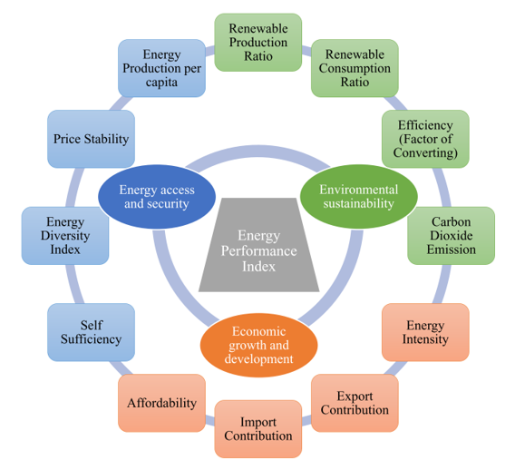

## Load packages

```r
library(dplyr)
```

```r
library(ggplot2)
library(tidyverse)
library(ggradar)
```

## Load data which has been preprocessed.

```r
energy <- read.csv('wide_data_fill_final.csv', header = T)
columns <- names(energy)
```

## Calculate 12 indicators for 3 indexes

### Environmental Sustainability

1. Renewable Energy Production Ratio It tells the proportion of renewable energy production and the total production. It shows the ability and consciousness of exact state to use renewable energy. The more percent of renewable energy we produce, the less potential of pollution and waste we will yield, the better for the environment.
   $$Renewable\ Energy\ Production\ Ratio = \frac{rewable\ energy\ production(billion~btu)}{total\ energy\ production(billion~btu)}$$

```r
## Extract production data
production <- energy %>%
  select(Year, StateCode, BMTCB, GETCB, HYTCB, WYTCB, SOTCB, NUETB, CLPRB, PAPRB, NGMPB, TEPRB) %>%
  mutate(Total_Production = BMTCB + GETCB + HYTCB + WYTCB + SOTCB + NUETB + CLPRB + PAPRB + NGMPB) %>%
  mutate(Renew_Ratio = (BMTCB + GETCB + HYTCB + WYTCB + SOTCB)/Total_Production)
```

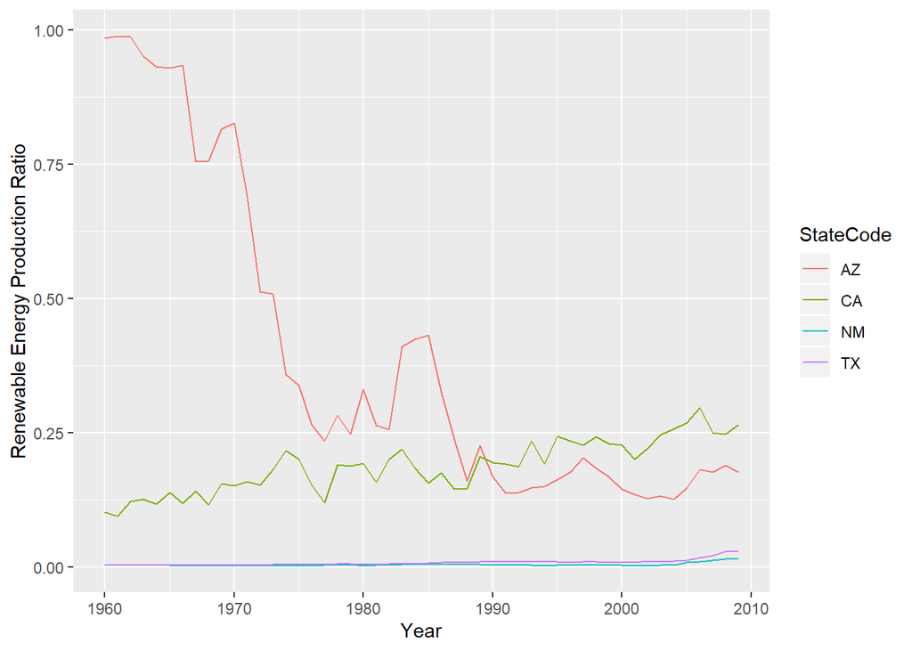

```r
ggplot(data = production, mapping = aes(x = Year, y = Renew_Ratio))+
  geom_line(mapping = aes(color = StateCode)) +
  labs(y = "Renewable Energy Production Ratio")
```

2. Renewable Energy Consumption Ratio It tells the proportion of renewable energy consumption and the total consumption. It shows the popularity of renewable energy in a state. Similar to the Renewable Production Ratio, The more percent of renewable energy we consume, the better for the environment.
   $$Renewable\ Energy\ Consumption\ Ratio = \frac{rewable\ energy\ consumption(billion~btu)}{total\ energy\ consumption(billion~btu)}$$

```r
## Extract consumption data
consumption <- energy %>%
  select(Year, StateCode, BMTCB, CLTCB, GETCB, HYTCB, NNTCB, PMTCB, WYTCB, SOTCB, NUETB, TETCB) %>%
  mutate(Total_Consumption = BMTCB + CLTCB + GETCB + HYTCB + NNTCB + PMTCB + WYTCB + SOTCB + NUETB) %>%
  mutate(Renew_Ratio = (BMTCB + GETCB + HYTCB + WYTCB + SOTCB)/Total_Consumption)
```

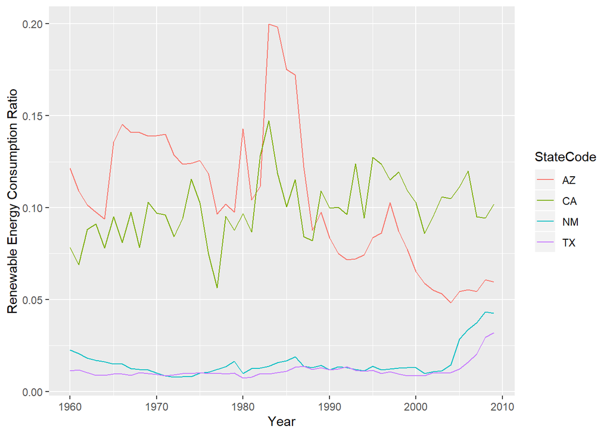

```r
ggplot(data = consumption, mapping = aes(x = Year, y = Renew_Ratio))+
  geom_line(mapping = aes(color = StateCode)) +
  labs(y = "Renewable Energy Consumption Ratio")
```

3. Efficiency (Factor of Converting) Because the energy department only provide factor of converting for three main energy: natural gas, petroleum and coal, so we can only use these three factors. It shows the efficiency of converting primary energy to electricity. Efficiency shows whether the energy had been maximally utilized. If we can take maximum use of every unit energy, we can waste less and help the environment much.
   $$Efficiency = \frac{1}{n} \sum_{i=1}^n {factor~of~converting~by~energy~type(million~btu~per~short~ton)}$$

```r
## MinMaxScaler
rescale01 <- function(x) {
  rng <- range(x, na.rm = TRUE)
  (x - rng[1]) / (rng[2] - rng[1])
}
rescale01_omit0 <- function(x) {
  y <- x[x!=0]
  rng <- range(y, na.rm = TRUE)
  for (i in seq(1, length(x), by=1)){
    if (x[i] != 0) x[i] = (x[i] - rng[1]) / (rng[2] - rng[1])
  }
  return (x)
}
```

```r
energy <- energy %>%
  mutate(
    CLEIK_scaled = rescale01(CLEIK),
    NGEIK_scaled = rescale01(NGEIK),
    PAEIK_scaled = rescale01(PAEIK)
  )
## Calculate efficiency
efficiency <- energy %>%
  select(Year, StateCode, CLEIK_scaled, NGEIK_scaled, PAEIK_scaled) %>%
  mutate(Efficiency = (CLEIK_scaled+NGEIK_scaled+PAEIK_scaled)/3)
```

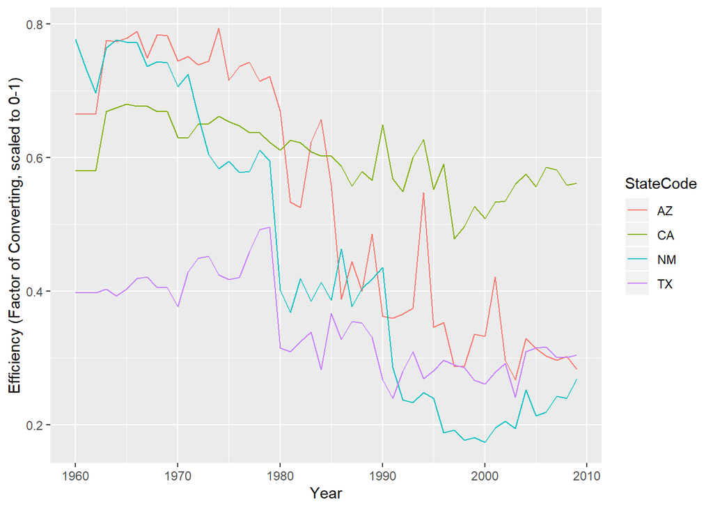

```r
ggplot(data = efficiency, mapping = aes(x = Year, y = Efficiency))+
  geom_line(mapping = aes(color = StateCode)) +
  labs(y = "Efficiency (Factor of Converting, scaled to 0-1)")
```

```r
## Bind data from different files
co2_emission <- rbind(co2az, co2ca, co2nm, co2tx) %>%
  select(year, StateCode, Total) %>%
  rename(Year=year, CO2_Emission=Total) %>%
  filter(Year<=2009)
## Extract consumption data
consumption2 <- energy %>%
  select(Year, StateCode, BMTCB, CLTCB, GETCB, HYTCB, NNTCB, PMTCB, WYTCB, SOTCB, NUETB, TETCB) %>%
  mutate(Total_Consumption = BMTCB + CLTCB + GETCB + HYTCB + NNTCB + PMTCB + WYTCB + SOTCB + NUETB) %>%
  select(Year, StateCode, Total_Consumption, TETCB)
## Take the log of consumption to prevent small values
co2_emission <- co2_emission %>%
  left_join(consumption2, by = c('Year', 'StateCode')) %>%
  mutate(Unit_CO2_Emission = CO2_Emission/log(Total_Consumption))
## MinMaxScaler
co2_emission <- co2_emission %>%
  mutate(Unit_CO2_Emission_scaled = 1 - rescale01(Unit_CO2_Emission))
```

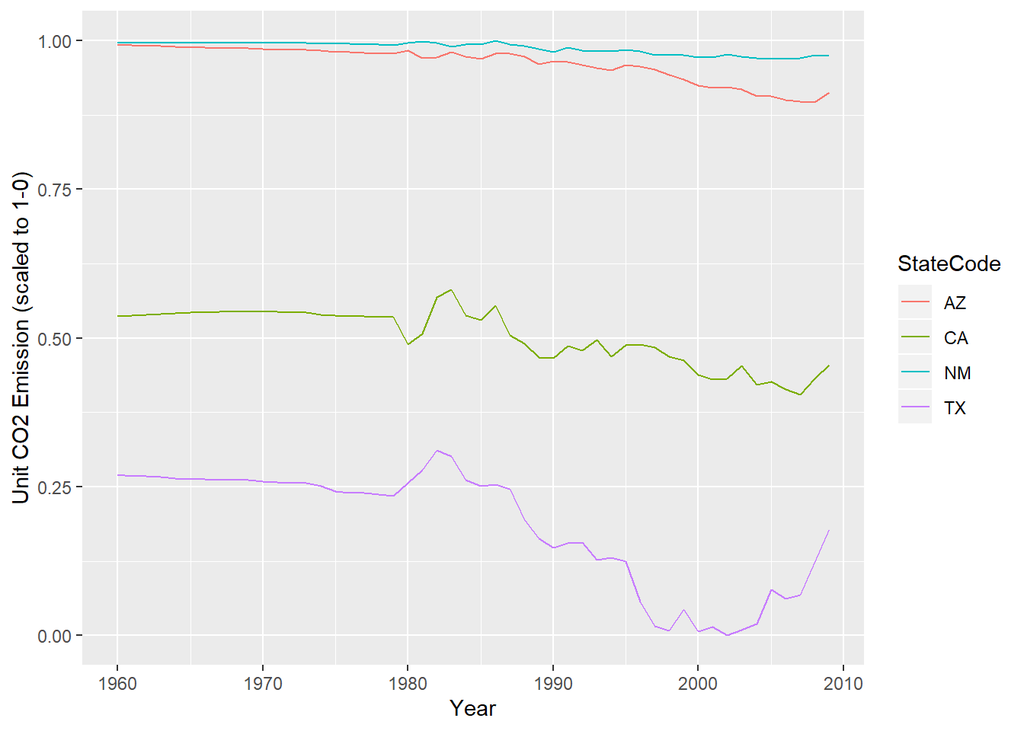

```r
ggplot(data = co2_emission, mapping = aes(x = Year, y = Unit_CO2_Emission_scaled))+
  geom_line(mapping = aes(color = StateCode)) +
  labs(y = "Unit CO2 Emission (scaled to 1-0)")
```

### Economic Growth and Development

1. Energy Intensity It is defined as GDP per unit energy use. It shows the contribution of per unit energy to the economy, which can also be used to compare the productivity of energy by state.
   $$Energy ~Intensity=\frac{GDP(million~dollars)}{total~energy~consumption(billion~btu)}$$

```r
gdp <- read.csv('GDP_chained.csv')
gdp <- gdp %>%
  gather('AZ', 'CA', 'NM', 'TX', key = 'StateCode', value = GDP_Chained) %>%
  filter(Year<=2009)
```

```r
intensity <- gdp %>%
  left_join(consumption, by = c('Year', 'StateCode')) %>%
  mutate(Energy_Intensity = GDP_Chained/Total_Consumption) %>%
  select(Year, StateCode, GDP_Chained, Total_Consumption, Energy_Intensity)
## MinMaxScaler
intensity <- intensity %>%
  mutate(Energy_Intensity_scaled = rescale01(Energy_Intensity))
```

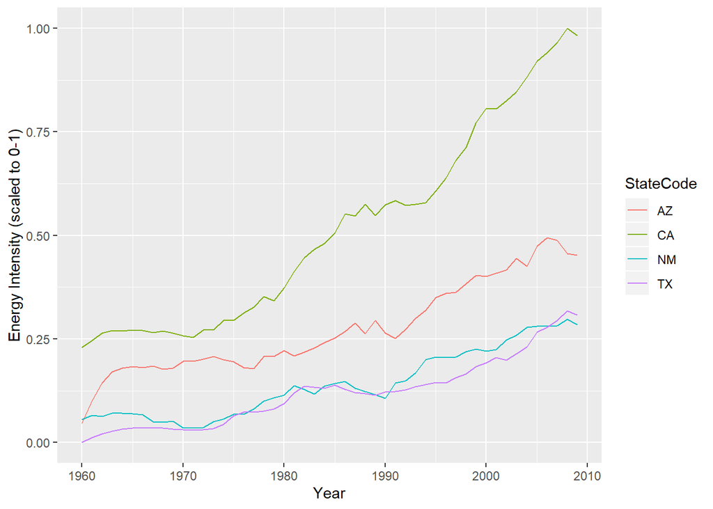

```r
ggplot(data = intensity, mapping = aes(x = Year, y = Energy_Intensity_scaled))+
  geom_line(mapping = aes(color = StateCode)) +
  labs(y = "Energy Intensity (scaled to 0-1)")
```

2. Export Contribution It is the proportion of energy export expenditure and GDP. It shows part of the contribution to total GDP made by energy production.
   $$Export ~Contribution=\frac{total~energy~export(million~dollars)}{GDP(million~dollars)}$$

```r
exp_imp <- energy %>%
  select(Year, StateCode, ELEXV, ELIMV) %>%
  left_join(gdp, by = c('Year', 'StateCode')) %>%
  mutate(Export_Contri = ELEXV/GDP_Chained,
         Import_Contri = ELIMV/GDP_Chained) %>%
  mutate(Export_Contri_scaled = rescale01(Export_Contri),
         Import_Contri_scaled = rescale01(Import_Contri))
```

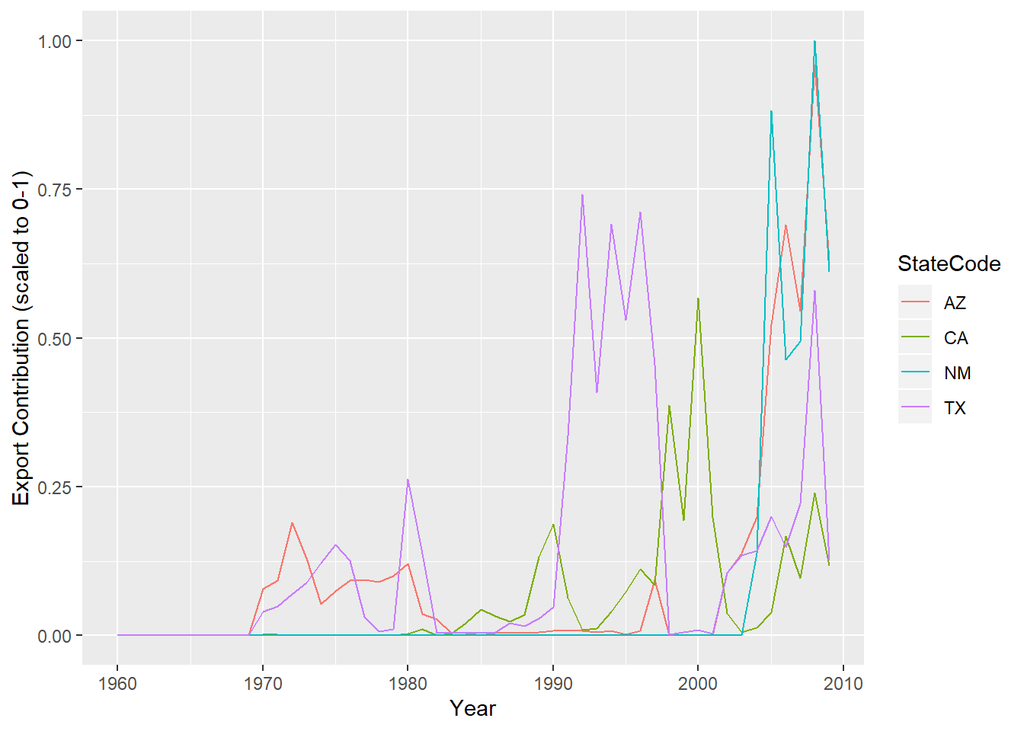

```r
ggplot(data = exp_imp, mapping = aes(x = Year, y = Export_Contri_scaled))+
  geom_line(mapping = aes(color = StateCode)) +
  labs(y = "Export Contribution (scaled to 0-1)")
```

3. Import Contribution Similiar to Export Contribution.
   $$Import ~Contribution=\frac{total~energy~import(million~dollars)}{GDP(million~dollars)}$$

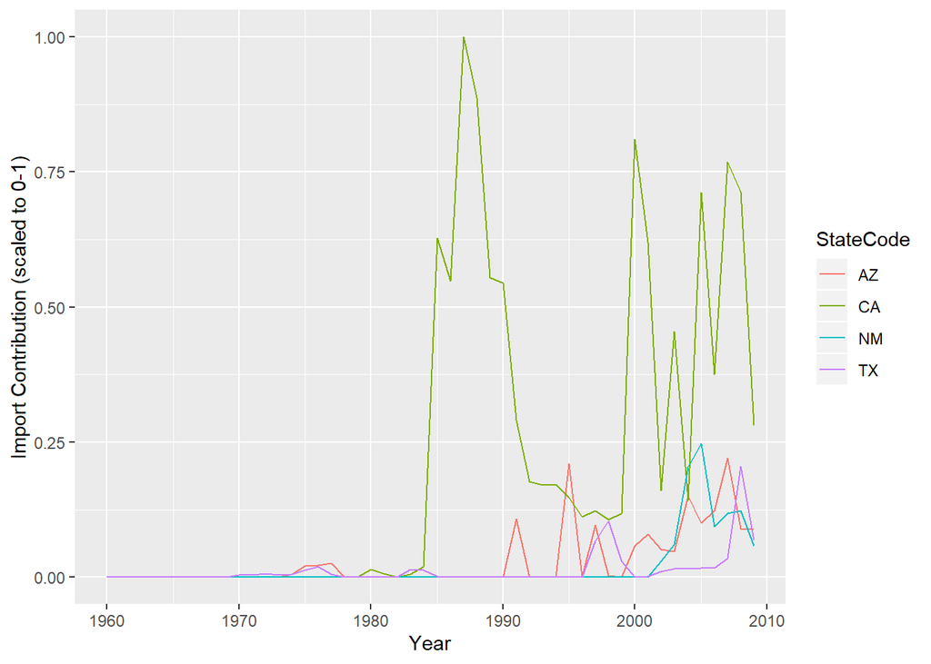

```r
ggplot(data = exp_imp, mapping = aes(x = Year, y = Import_Contri_scaled))+
  geom_line(mapping = aes(color = StateCode)) +
  labs(y = "Import Contribution (scaled to 0-1)")
```

4. Affordability It is represented by the electricity prices for industry. Empirically, more business owners want to produce more when the electricity price is lower, which subsequently can contribute to the growth of GDP.
   $$Affordability=1-electricity~ price~(MaxMin~scaled)$$

```r
afford <- energy %>%
  select(Year, StateCode, ESTCD) %>%
  mutate(ESTCD_scaled = 1 - rescale01_omit0(ESTCD))
```

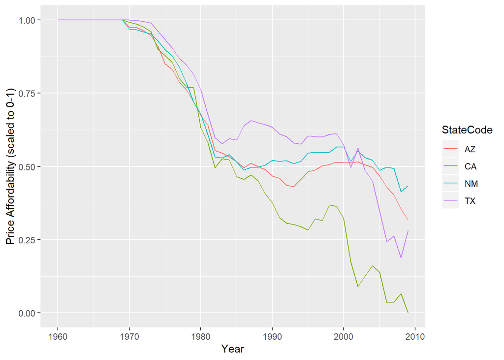

```r
ggplot(data = afford, mapping = aes(x = Year, y = ESTCD_scaled))+
  geom_line(mapping = aes(color = StateCode)) +
  labs(y = "Price Affordability (scaled to 0-1)")
```

### Energy Access and Security

1. Self Sufficiency It measures the ability for a state survive from import block. We take the electricity consumption to analysis. It is defined as the ratio of energy self-production and energy total consumption. If the import of electricity occupies a larger proportion of the total consumption, the state is more dependent on other states or other countries. Under this measure, dependence is not a good character. The less dependent on other regions, the higher the self sufficiency is.
   $$Self ~Sufficiency=1-\frac{electricity ~import(billion~btu)}{electricity ~total~ consumption(billion~btu)}$$

```r
self_suff <- energy %>%
  select(Year, StateCode, ELIMB, ESTCB) %>%
  mutate(Self_Suff = 1 - ELIMB/ESTCB)
```

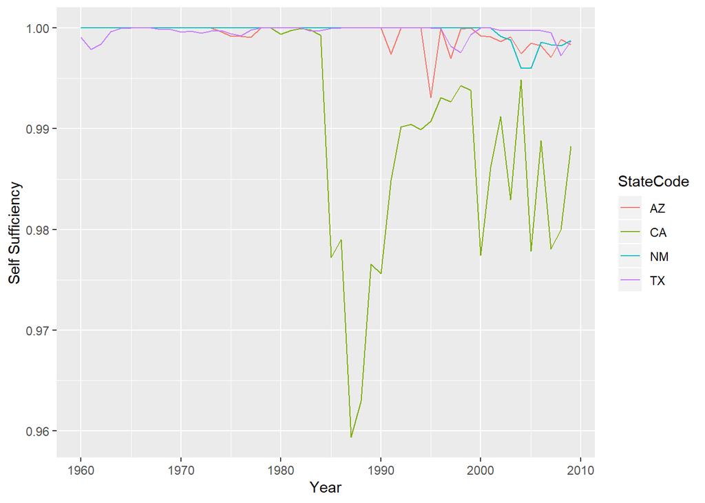

```r
ggplot(data = self_suff, mapping = aes(x = Year, y = Self_Suff))+
  geom_line(mapping = aes(color = StateCode)) +
  labs(y = "Self Sufficiency")
```

2. Energy Diversity Index It is an indicator quantify the diversity of a state’s energy structure, the higher the diversity index is, the more energy types are and the more evenly those types of energy are distributed in the structure. We perceive that if one of the energy is confronted by import block or other unexpected events, the state with diverse energy supply will be little influenced and function much better than the state which mainly depend on just on or two types of energy. However, we’ll finally reach a point that fossil fuels will be used up and the diversity must decline. Since in the short term there will be little concern about the energy exhaustion, we still use this measure. To calculate the diversity, we gain the help of **Herfindahl index**.
   $$Energy ~Diversity ~Index=1- \sum_{i=1}^n P_i^2$$

$\qquad where~P_i=the~percentage~of~each~ energy~ type~ consumption~ and~ total~ energy ~consumption.$

```r
## BMTCB + CLTCB + GETCB + HYTCB + NNTCB + PMTCB + WYTCB + SOTCB + NUETB = Total
edi <- consumption %>%
  mutate(EDI = 1 - ((BMTCB/Total_Consumption)^2+
                   (CLTCB/Total_Consumption)^2+
                   (GETCB/Total_Consumption)^2+
                   (HYTCB/Total_Consumption)^2+
                   (NNTCB/Total_Consumption)^2+
                   (PMTCB/Total_Consumption)^2+
                   (WYTCB/Total_Consumption)^2+
                   (SOTCB/Total_Consumption)^2+
                   (NUETB/Total_Consumption)^2))
```

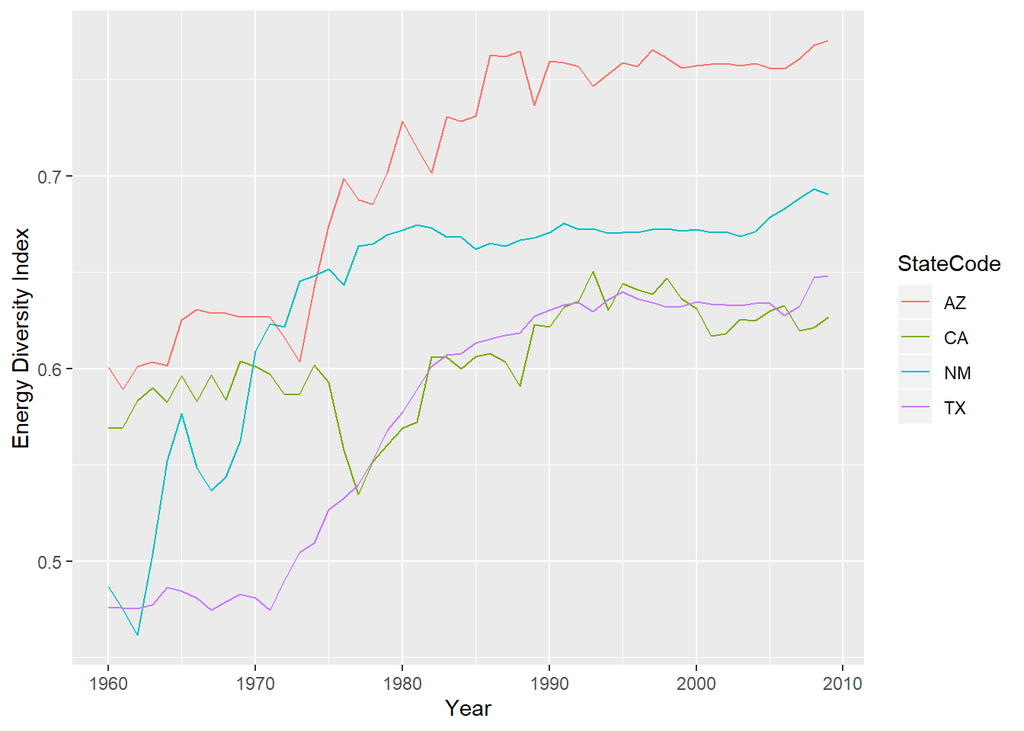

```r
ggplot(data = edi, mapping = aes(x = Year, y = EDI))+
  geom_line(mapping = aes(color = StateCode)) +
  labs(y = "Energy Diversity Index")
```

3. Price Stability It measures the stability of energy price. Price stability influence the anticipation of business owners and individuals. If the energy price varies so severely, energy-intensive corporations will suffer heavy cost burden. Consequently, it may prevent investors from investing money into those corporations. Moreover, individuals may conceive it as an unsecure governmental or economical issue, which may cause complaints and social problems. We use the change percentage of annual primary energy average price (dollars per million btu) to quantify this indicator.
   $$Price ~Stability=1-\frac{ \left| current ~year's ~price-last~ year's ~price \right|}{last ~year's~ price}$$

```r
price <- energy[c('Year','StateCode','PETCD')]
p_az <- filter(price, StateCode=='AZ')
p_ca <- filter(price, StateCode=='CA')
p_nm <- filter(price, StateCode=='NM')
p_tx <- filter(price, StateCode=='TX')
```

```r
## calculate price stability
cal_ps <- function(p) {
  ## 从1970开始(1971才能算)，前面是没有数据的
  res <- c()
  for (i in seq(1, 11, by=1)){
    res[i] <- 1
  }
  for (i in seq(12, length(p), by=1)){
    res[i] <- 1 - abs(p[i] - p[i-1])/p[i-1]
  }
  return(res)
}
```

```r
ps_az <- p_az %>%
  mutate(Price_Stab = cal_ps(PETCD))
ps_ca <- p_ca %>%
  mutate(Price_Stab = cal_ps(PETCD))
ps_nm <- p_nm %>%
  mutate(Price_Stab = cal_ps(PETCD))
ps_tx <- p_tx %>%
  mutate(Price_Stab = cal_ps(PETCD))
ps <- rbind(ps_az, ps_ca, ps_nm, ps_tx)
```

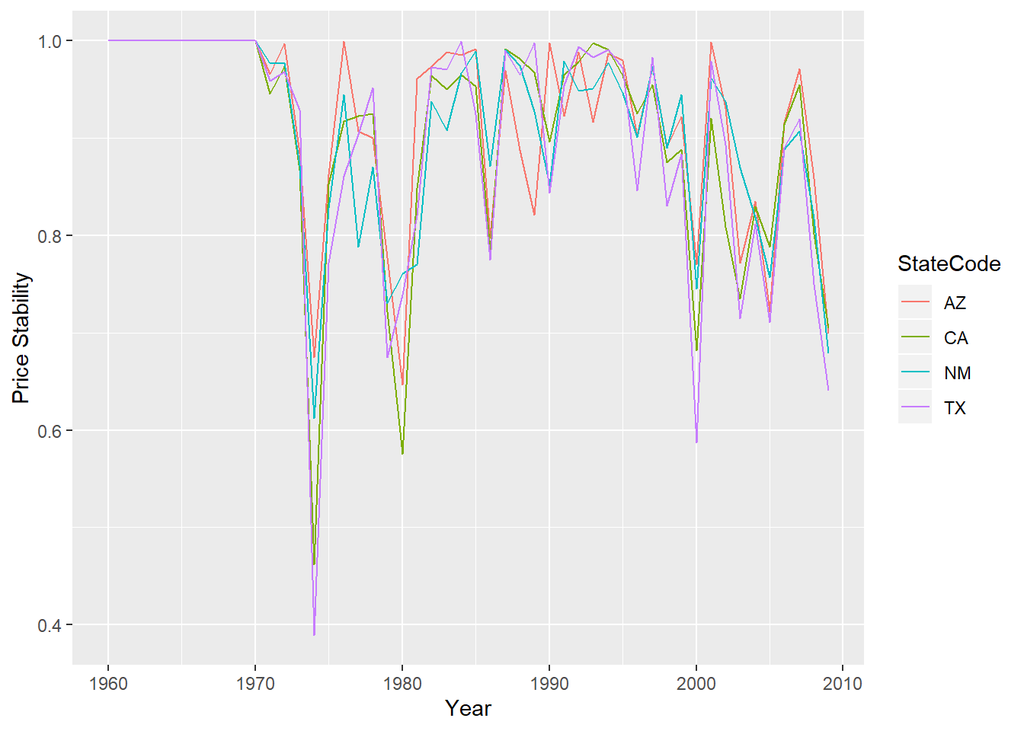

```r
ggplot(data = ps, mapping = aes(x = Year, y = Price_Stab))+
  geom_line(mapping = aes(color = StateCode)) +
  labs(y = "Price Stability")
```

4. Energy Production per capita (million btu per person) It indicates the average ability of a state to generate energy. If one person can produce more energy, there is less worry about energy accessibility.
   $$Energy ~Production ~per~ capita=\frac{total ~primary ~energy~ production(billion~btu)}{population ~size(thousand)}$$

```r
eppc <- energy %>%
  left_join(production, by = c('Year', 'StateCode')) %>%
  select('Year', 'StateCode', 'TPOPP', 'Total_Production') %>%
  mutate(EPPC = Total_Production/TPOPP) %>%
  mutate(EPPC_scaled = rescale01(EPPC))
```

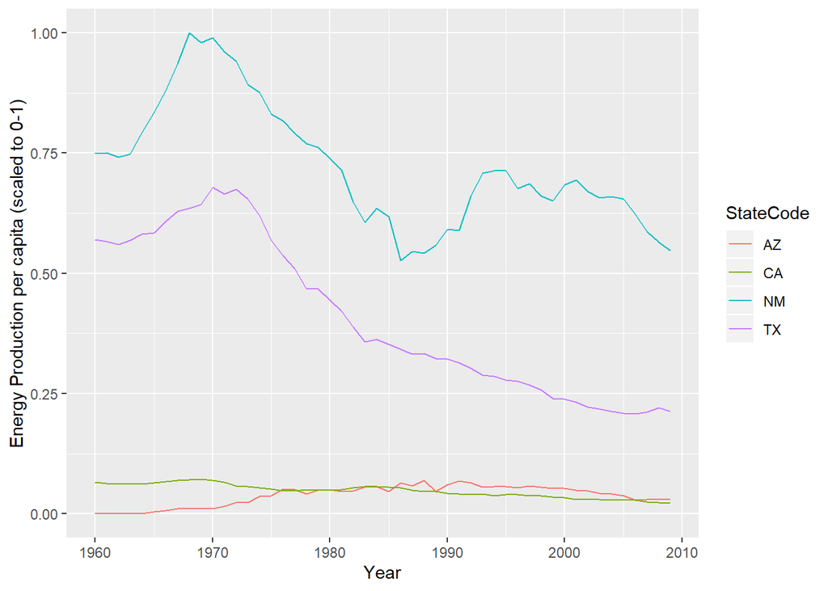

```r
ggplot(data = eppc, mapping = aes(x = Year, y = EPPC_scaled))+
  geom_line(mapping = aes(color = StateCode)) +
  labs(y = "Energy Production per capita (scaled to 0-1)")
```

## Apply AHP (Analytic Hierarchy Process)

The analytic hierarchy process (AHP) is a structured technique for organizing and analyzing complex decisions, based on mathematics and psychology. It can generate weights from a combined way of subjectivity and objectivity. Here we use AHP to determine the weights of each indicators coupled with their mother index.

```r
##输入：judgeMatrix 判断矩阵；round 结果约分位数
##输出：权重
weight <- function (judgeMatrix, round=3) {
  n = ncol(judgeMatrix)
  cumProd <- vector(length=n)
  cumProd <- apply(judgeMatrix, 1, prod)  ##求每行连乘积
  weight <- cumProd^(1/n)  ##开n次方(特征向量)
  weight <- weight/sum(weight) ##求权重
  round(weight, round)
}
##输入：judgeMatrix
##输出：CI, CR
CRtest <- function (judgeMatrix, round=3){
  RI <- c(0, 0, 0.58, 0.9, 1.12, 1.24, 1.32, 1.41, 1.45, 1.49, 1.51) #随机一致性指标
  Wi <- weight(judgeMatrix)  ##计算权重
  n <- length(Wi)
  if(n > 11){
    cat("判断矩阵过大,请少于11个指标 \n")
  }
  if (n > 2) {
    W <- matrix(Wi, ncol = 1)
    judgeW <- judgeMatrix %*% W
    JudgeW <- as.vector(judgeW)
    la_max <- sum(JudgeW/Wi)/n
    CI = (la_max - n)/(n - 1)
    CR = CI/RI[n]
    cat("CI=", round(CI, round), "\n")
    cat("CR=", round(CR, round), "\n")
    if (CR <= 0.1) {
      cat(" Passed CR test! \n")
      cat("Weights: ", round(Wi, round), "\n")
    }
    else {
      cat("Please adjust the judge matrix, make CR < 0.1 \n")
      Wi = NULL
    }
  }
  else if (n <= 2) {
    return(Wi)
  }
  consequence <- c(round(CI, round), round(CR, round))
  names(consequence) <- c("CI", "CR")
  consequence
}
```

### Environmental Sustainability

```r
## the order of 4 indicators is RPR, RCR, EFF, CO2
## generate judgeMatrix
b <- c(1,3,1/3,1/2,
       1/3,1,1/5,2,
       3,5,1,4,
       1/2,1/2,1/4,1)
judgeMatix <- matrix(b, ncol=4)
```

```r
## calculate the Consistency Index and Consistency Ratio
CRtest(judgeMatix)
```

```
## CI= 0.013
## CR= 0.014
##  Passed CR test!
## Weights:  0.197 0.388 0.084 0.331
```

```
##    CI    CR
## 0.013 0.014
```

### Economic Growth and Development

```r
## the order of 4 indicators is EI, ExpContri, ImpContri, Aff
## generate judgeMatrix
b <- c(1,1/2,1/3,1/5,
       2,1,1/2,1/3,
       3,2,1,2/3,
       5,3,3/2,1)
judgeMatix <- matrix(b, ncol=4)
```

```r
## calculate the Consistency Index and Consistency Ratio
CRtest(judgeMatix)
```

```
## CI= 0.003
## CR= 0.003
##  Passed CR test!
## Weights:  0.485 0.273 0.147 0.095
```

```
##    CI    CR
## 0.003 0.003
```

### Energy Access and Security

```r
## the order of 4 indicators is SelfSuff, EDI, PS, EPPC
## generate judgeMatrix
b <- c(1,5,2,4,
       1/5,1,1/3,1/2,
       1/2,3,1,2,
       1/4,2,1/2,1)
judgeMatix <- matrix(b, ncol=4)
```

```r
## calculate the Consistency Index and Consistency Ratio
CRtest(judgeMatix)
```

```
## CI= 0.007
## CR= 0.008
##  Passed CR test!
## Weights:  0.081 0.476 0.155 0.288
```

```
##    CI    CR
## 0.007 0.008
```

## Generate the indexes for each state

```r
## set weights
es_w <- matrix(c(0.197, 0.388, 0.084, 0.331), ncol=1)
eg_w <- matrix(c(0.485, 0.273, 0.147, 0.095), ncol=1)
ea_w <- matrix(c(0.081, 0.476, 0.155, 0.288), ncol=1)
```

```r
## combine indicators
## ES
es <- production %>%
  select('Year', 'StateCode', 'Renew_Ratio') %>%
  transmute(Year = Year,
            StateCode = StateCode,
    renew_ratio_production = Renew_Ratio) %>%
  left_join(consumption, by = c('Year', 'StateCode')) %>%
  mutate(renew_ratio_consumption = Renew_Ratio) %>%
  left_join(efficiency, by = c('Year', 'StateCode')) %>%
  mutate(efficiency_factor_converting = Efficiency) %>%
  left_join(co2_emission, by = c('Year', 'StateCode')) %>%
  mutate(unit_co2_emission = Unit_CO2_Emission_scaled) %>%
  select('Year', 'StateCode', 'renew_ratio_production', 'renew_ratio_consumption',
         'efficiency_factor_converting', 'unit_co2_emission') %>%
   mutate(es = matrix(c(renew_ratio_production,
                       renew_ratio_consumption,
                       efficiency_factor_converting,
                       unit_co2_emission), ncol=4)%*%es_w)
## EG
eg <- intensity %>%
  select('Year', 'StateCode', 'Energy_Intensity_scaled') %>%
  mutate(energy_intensity = Energy_Intensity_scaled) %>%
  left_join(exp_imp, by = c('Year', 'StateCode')) %>%
  mutate(export_contribution = Export_Contri_scaled,
         import_contribution = Import_Contri_scaled) %>%
  left_join(afford, by = c('Year', 'StateCode')) %>%
  mutate(affordability = ESTCD_scaled) %>%
  select('Year', 'StateCode', 'energy_intensity', 'export_contribution',
         'import_contribution', 'affordability') %>%
   mutate(eg = matrix(c(energy_intensity,
                       export_contribution,
                       import_contribution,
                       affordability), ncol=4)%*%eg_w)
## EA
ea <- self_suff %>%
  select('Year', 'StateCode', 'Self_Suff') %>%
  mutate(self_sufficiency = Self_Suff) %>%
  left_join(edi, by = c('Year', 'StateCode')) %>%
  mutate(energy_diversity_index = EDI) %>%
  left_join(ps, by = c('Year', 'StateCode')) %>%
  mutate(price_stability = Price_Stab) %>%
  left_join(eppc, by = c('Year', 'StateCode')) %>%
  mutate(energy_production_per_capita = EPPC_scaled) %>%
  select('Year', 'StateCode', 'self_sufficiency', 'energy_diversity_index',
         'price_stability', 'energy_production_per_capita') %>%
   mutate(ea = matrix(c(self_sufficiency,
                       energy_diversity_index,
                       price_stability,
                       energy_production_per_capita), ncol=4)%*%ea_w)
```

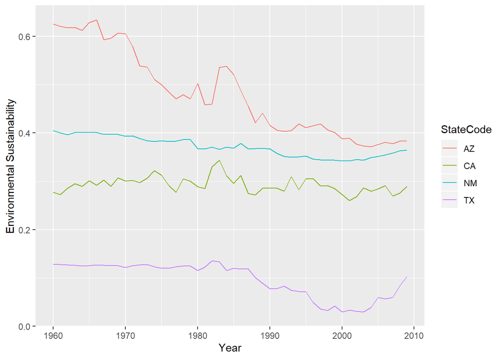

```r
ggplot(data = es, mapping = aes(x = Year, y = es))+
  geom_line(mapping = aes(color = StateCode)) +
  labs(y = "Environmental Sustainability")
```

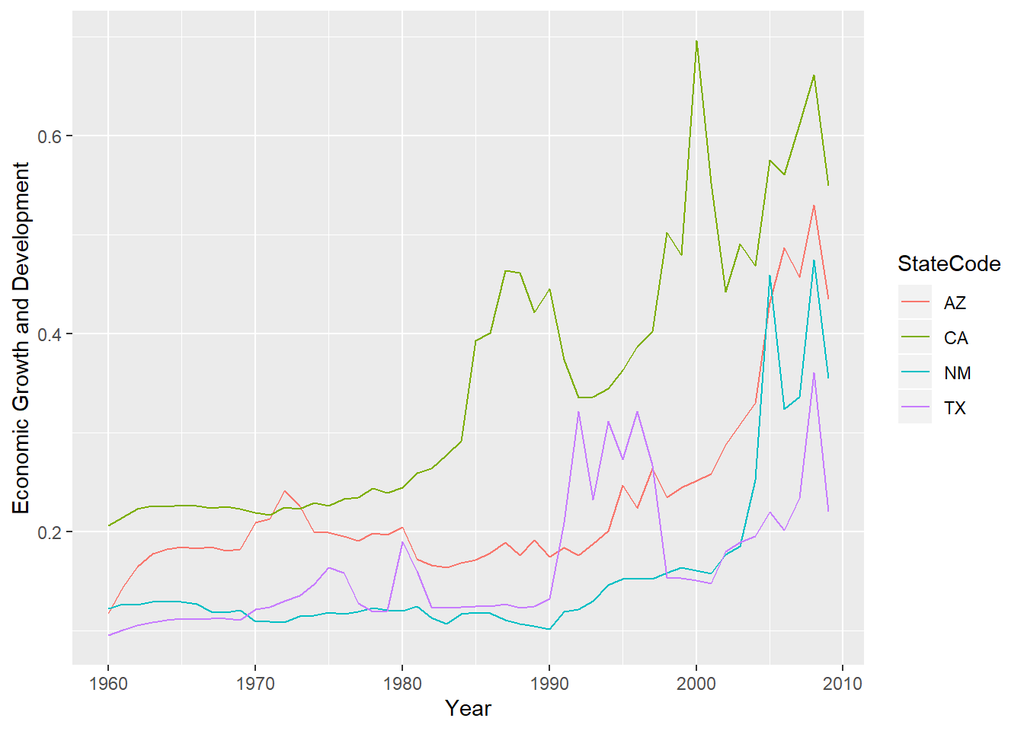

```r
ggplot(data = eg, mapping = aes(x = Year, y = eg))+
  geom_line(mapping = aes(color = StateCode)) +
  labs(y = "Economic Growth and Development")
```

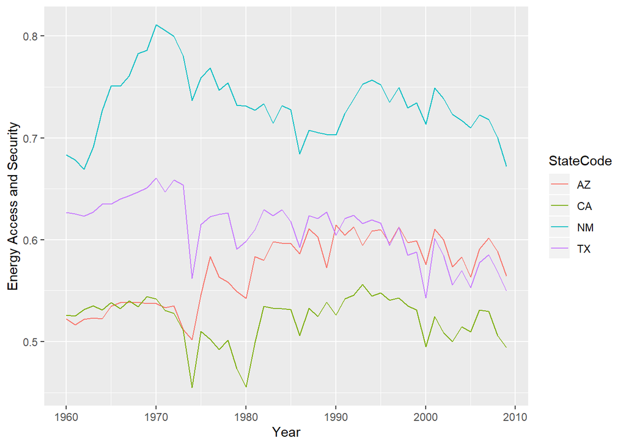

```r
ggplot(data = ea, mapping = aes(x = Year, y = ea))+
  geom_line(mapping = aes(color = StateCode)) +
  labs(y = "Energy Access and Security")
```

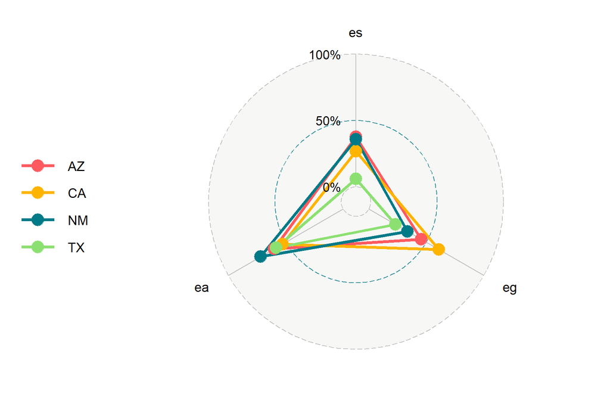

```r
index_2007 <- es %>%
  left_join(eg, by = c('Year', 'StateCode')) %>%
  left_join(ea, by = c('Year', 'StateCode')) %>%
  filter(Year == 2007) %>%
  select('StateCode', 'es', 'eg', 'ea')
ggradar(index_2007)
```

```r
index_2007 <- index_2007 %>%
  mutate(average = (es+eg+ea)/3)
index_2007
```

```
##   StateCode         es        eg        ea   average
## 1        AZ 0.37795874 0.4568571 0.6019171 0.4789110
## 2        CA 0.26927682 0.6115804 0.5294943 0.4701172
## 3        NM 0.35883011 0.3360895 0.7180236 0.4709811
## 4        TX 0.05995843 0.2338283 0.5852338 0.2930069
```

```r
index_2007.T <- t(index_2007[,2:ncol(index_2007)])
colnames(index_2007.T) <- index_2007[,1]
index_2007.T <- data.frame(index_2007.T)
```

```r
index_2007.T <- index_2007.T %>%
  mutate(Indexes = row.names(index_2007.T)) %>%
  select('Indexes', 'AZ', 'CA', 'NM', 'TX')
```

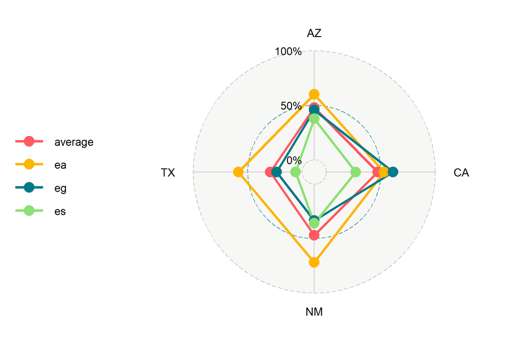

```r
ggradar(index_2007.T)
```

For a specific year, we can draw a radar chart to compare among the four states. As we can see in 2007, Arizona, California and New Mexico win one index respectively. Thus, it is very different to determine the best state. If we set the weights of the three indexes evenly, we can see that Arizona reaches the highest average of 0.4789. However, different people, different governments will see things differently from different aspects. The weights can also be determined using AHP or simply by human. Therefore, we just leave the final step open to everyone who are interested in this index system and for the users who have different situations and concerns.